# Question

Luis busca una contraseña segura para un sitio web de descargas de música. Para crear una contraseña segura se debe tener en cuenta 12 consejos importantes.

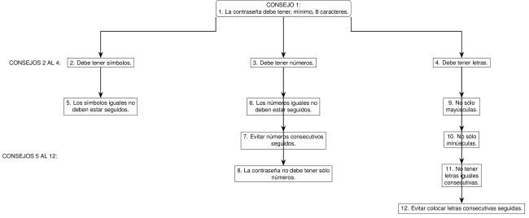

Un método para medir la seguridad de la contraseña, basado en la cantidad de consejos cumplidos, se resume en la siguiente tabla:

| N.º de consejos cumplidos | Nivel de seguridad |
| --- | --- |
| 0-2 | Muy bajo |
| 3-5 | Bajo |
| 6-8 | Medio |
| 9-10 | Alto |
| 11-12 | Muy alto |

Al usar su gestor de contraseñas se genera la contraseña |y.QUYgpqE

Luis comprueba que la contraseña cumple con un total de ##ANSWER1## consejos. Por tanto, su nivel de seguridad es ##ANSWER2##

# Solution

Luis comprueba que la contraseña cumple con 7 consejos. Por tanto, su nivel de seguridad es Medio.

Explicación de los consejos cumplidos:

1. Longitud mínima de 8 caracteres: Sí
2. Incluye símbolos: Sí
3. Incluye números: No
4. Incluye letras: Sí
5. No tiene símbolos iguales seguidos: Sí
6. No tiene números iguales seguidos: No evaluado (no hay números)
7. No tiene números consecutivos seguidos: No evaluado (no hay números)
8. No tiene solo números: No evaluado (no hay números)
9. No tiene solo mayúsculas: Sí
10. No tiene solo minúsculas: Sí
11. No tiene letras iguales consecutivas: Sí
12. No tiene letras consecutivas seguidas: No

Contraseña evaluada: |y.QUYgpqE

Número de consejos cumplidos: 7

Nivel de seguridad calculado: Medio

Número total de consejos cumplidos: 7 Nivel de seguridad resultante: Medio

# Meta-information

exname: Seguridad de Contraseña extype: cloze exclozetype: num|string exsolution: 7|Medio extol: 0 exsection: Seguridad Informática exextra[Type]: Conceptual